# #TidyTuesday Submission

Data Science for Biologists, Spring 2020

Nicholas Paterna

February 17, 2020

### TidyTuesday Week 8

> Hi, this is my first time attempting to make a figure for #TidyTuesday! I am a student at Rowan University in Biochemistry with *ZERO* experience in coding at all. R is my first language and I am very happy to be learning it, I hope to apply the knowledge I gain from this trend in my own research in Rowan’s molecular biology department where I do work with Benjamin Carone, PhD. Let me know what you think!!

```r
food_consumption %>%
  group_by(food_category) %>%
  summarize("total_consumption" = sum(consumption)) %>%

  ggplot(aes(y = total_consumption, x = fct_reorder(food_category, total_consumption), fill = food_category)) +
  geom_col(position = "dodge") +
  labs(x = "", y = "Total Consumption", fill = "Food Category", title = "Cumulative Food Consumption by Category") +
  theme(axis.text.x=element_text(angle=45, hjust=1), legend.position= "NONE") -> plot1
```

```
## group_by: one grouping variable (food_category)
```

```
## summarize: now 11 rows and 2 columns, ungrouped
```

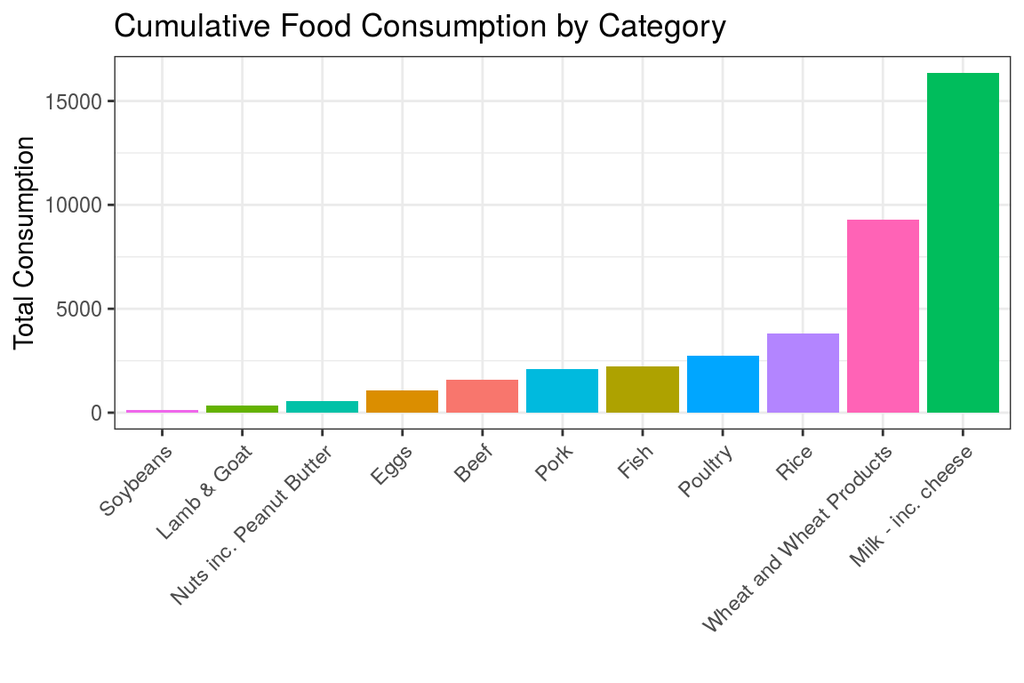

```r
ggsave("titdytuesday_week8.png", plot1, height = 4, width = 6)
plot1
```

> In my data science course we are currently working through the basics of dplyr for piping commands and manipulating data to our liking. In the figure I made above I decided to examine the easiest portion of the food consumption data to understand; actual consumption. The data represented is the sum of all the categories per country. I was surprised that dairy products were the most consumed globally, I assumed that one of the meats would surpass this category. I really enjoyed playing around with this data set and actually tried creating several different figures before settling on this one specifically. Manipulating the data as I did here helped me learn how to use a little bit of the **forcats** package and apply skills I have already learned in class!